# Analysis of Munc on Bassoon Data

```r
    knitr::opts_knit$set(root.dir = normalizePath("../../Desktop/Kittel_Lab/macro_output/"))
```

```r
getwd()
```

```
## [1] "/Users/tbullmann/Desktop/Kittel_Lab/macro_output"
```

```r
options(scipen = 999)  # disable scientific format for number
options(digits= 3)     # use 3 digits
library(dplyr)         # for multivariate summaries
```

```r
library(lattice)       # for multivariate plots
```

# Data

## Load data

```r
filenames <- Sys.glob("*.bassoon.csv")  # get a list of bassoon results
BassoonBlobs <- lapply(filenames, function(.file){
  dat<-read.csv(.file, header=T)
  dat$filename<-as.character(.file)
  dat    # return the dataframe
})
BassoonBlobs <- do.call(rbind, BassoonBlobs) # combine into a single dataframe
```

## Parsing filenames

```r
# E followed by a integer number of any length, followed by a _ and then anything
BassoonBlobs$experiment <- sub("E(\\d*)_.*", "\\1", BassoonBlobs$filename)
# anything followed by _ then a string without _, followed by _ and then again anything
BassoonBlobs$treatment <- sub(".*_([^_]+)_.*", "\\1", BassoonBlobs$filename)
# last number before the dot = anything followed by a number of any length, followed by a . and anything
BassoonBlobs$dish <- sub(".*_(\\d*)\\..*", "\\1", BassoonBlobs$filename)
```

## Cleanup

Munc counts are integers

```r
BassoonBlobs$Munc_count <- as.integer(BassoonBlobs$Munc_count)
```

Removing Munc count of background

```r
BassoonBlobs<-BassoonBlobs[!(BassoonBlobs$Bassoon_id==0),]
```

```r
BassoonBlobs$Marker <- ifelse(BassoonBlobs$experiment %in% c(6,7,9), "VGAT", "VGluT1")
```

# Show the data

```r
head(BassoonBlobs)
```

|  | Bassoon_id | Bassoon_area | Marker_overlap | Munc_count | Munc_density | filename | experiment | treatment | dish | Marker |
| --- | --- | --- | --- | --- | --- | --- | --- | --- | --- | --- |
| 2 | 1 | 40 | 1 | 0 | 0.000 | E2_TTX_5.png.bassoon.csv | 2 | TTX | 5 | VGluT1 |
| 3 | 2 | 204 | 1 | 0 | 0.000 | E2_TTX_5.png.bassoon.csv | 2 | TTX | 5 | VGluT1 |
| 4 | 3 | 106 | 1 | 1 | 0.009 | E2_TTX_5.png.bassoon.csv | 2 | TTX | 5 | VGluT1 |
| 5 | 4 | 291 | 1 | 2 | 0.007 | E2_TTX_5.png.bassoon.csv | 2 | TTX | 5 | VGluT1 |
| 6 | 5 | 56 | 1 | 0 | 0.000 | E2_TTX_5.png.bassoon.csv | 2 | TTX | 5 | VGluT1 |
| 7 | 6 | 95 | 1 | 0 | 0.000 | E2_TTX_5.png.bassoon.csv | 2 | TTX | 5 | VGluT1 |

# Effect of TTX on Munc_count

## All active zones

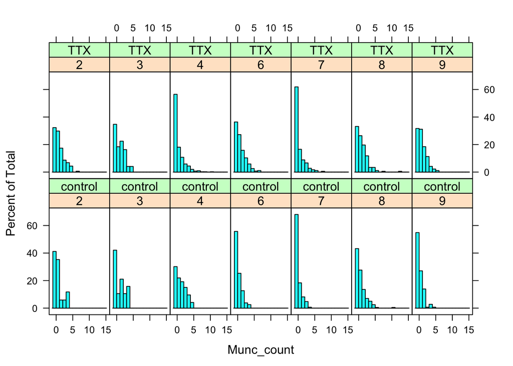

```r
histogram(~Munc_count|experiment+treatment,auto.key=TRUE,data=BassoonBlobs, breaks=-1:15)
```

We can see that each experiment has a similar distribution for the *Munc_count*.

```r
sem <-function (x) {sd(x)/sqrt(length(x)-1)}
BassoonBlobs %>% group_by(experiment, treatment) %>% summarise_each(list(mean=mean, sem=sem, sd=sd, n=length), Munc_count) %>% ungroup
```

| experiment | treatment | mean | sem | sd | n |
| --- | --- | --- | --- | --- | --- |
| 2 | control | 1.118 | 0.3410 | 1.364 | 17 |
| 2 | TTX | 1.441 | 0.1172 | 1.483 | 161 |
| 3 | control | 1.474 | 0.3632 | 1.541 | 19 |
| 3 | TTX | 1.490 | 0.2065 | 1.431 | 49 |
| 4 | control | 1.644 | 0.1761 | 1.494 | 73 |
| 4 | TTX | 1.027 | 0.0810 | 1.637 | 409 |
| 6 | control | 0.722 | 0.1131 | 0.999 | 79 |
| 6 | TTX | 1.382 | 0.0925 | 1.523 | 272 |
| 7 | control | 0.517 | 0.0734 | 0.886 | 147 |
| 7 | TTX | 0.845 | 0.1059 | 1.421 | 181 |

[output cut: 4 more lines]

We can see that in most cases (except experiment 4) the Munc_count increases.

*Note* that variance is not the same for each group. In fact *count data* often follow a Poisson distribution for which mean and variance are the same. In the following we we use a variance stabilizing transformation named Anscombe transformation to convert this Poisson distribution to a Gaussian distribution, for which we can calculate mean and sd as well as run the t-test.

```r
anscombe <- function (x) {2*sqrt(x+3/8)}   # variance stabilizing transformation for Poisson to Gaussian distribution
amean <- function (x) {mean(anscombe(x))}
asd <- function (x) {sd(anscombe(x))}
asem <-function (x) {asd(x)/sqrt(length(x)-1)}

BassoonBlobs %>% group_by(experiment, treatment) %>% summarise_each(list(mean=amean, sem=asem, sd=asd, n=length), Munc_count) %>% ungroup
```

| experiment | treatment | mean | sem | sd | n |
| --- | --- | --- | --- | --- | --- |
| 2 | control | 2.22 | 0.2622 | 1.049 | 17 |
| 2 | TTX | 2.47 | 0.0853 | 1.078 | 161 |
| 3 | control | 2.46 | 0.2813 | 1.193 | 19 |
| 3 | TTX | 2.51 | 0.1579 | 1.094 | 49 |
| 4 | control | 2.62 | 0.1307 | 1.109 | 73 |
| 4 | TTX | 2.07 | 0.0567 | 1.145 | 409 |
| 6 | control | 1.91 | 0.0975 | 0.861 | 79 |
| 6 | TTX | 2.41 | 0.0670 | 1.103 | 272 |
| 7 | control | 1.72 | 0.0650 | 0.786 | 147 |
| 7 | TTX | 1.94 | 0.0786 | 1.055 | 181 |

[output cut: 4 more lines]

Now the variance looks more similar for each group (control vs TTX) and we can run a little t-Test on each experiment. **Note** that this is without correction for multiple comparisons.

```r
BassoonBlobs %>% group_by(experiment) %>% summarise(pval = t.test(anscombe(Munc_count) ~ treatment, var.equal = TRUE)$p.value) %>% ungroup
```

| experiment | pval |
| --- | --- |
| 2 | 0.3637430718 |
| 3 | 0.8727364318 |
| 4 | 0.0001835252 |
| 6 | 0.0002378631 |
| 7 | 0.0334208574 |
| 8 | 0.0280676767 |
| 9 | 0.0000000678 |

### Summary

Experiments 2 and 3 (done with Sakamoto Munc antibody) do not show a significant change, whereas experiment 4 shows a significant reduction reduction. The remaining experiments show a significant increase in Munc_count for *all synapses*.

There are two types of synapses, excitatory (VGluT1) and inhibitory (VGAT).

*Note* Most of the synapses are excitatory, therefore increase should be due to excitatry synapses.

## Only active zones belonging to VGAT or VGluT1 marker

The active zones belong to either excitatory or inhibitory synapses, which are labelled with VGluT1 or VGAT, respectively. We now restict the analysis to active zones which overlap with this marker for the synapse type..

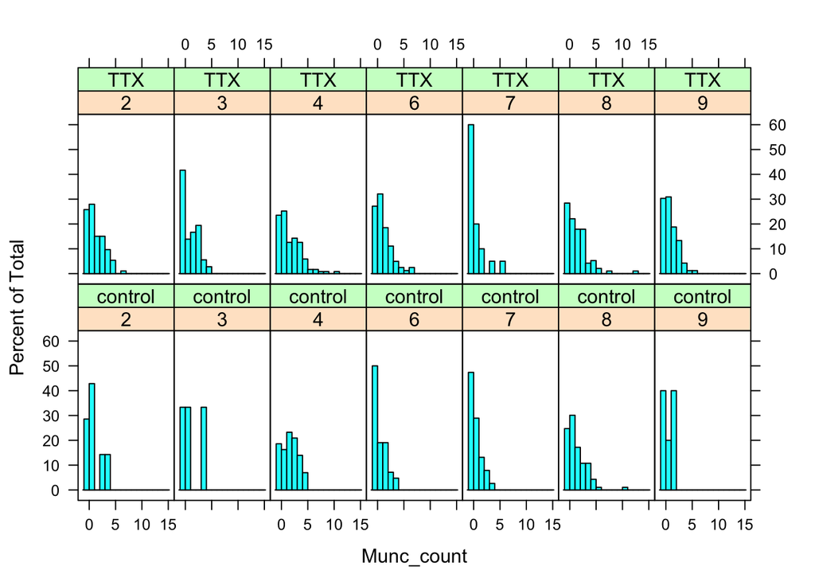

```r
histogram(~Munc_count|experiment+treatment,auto.key=TRUE,data=subset(BassoonBlobs,Marker_overlap==1), breaks=-1:15)
```

Again summary statistitics without Anscombe..

```r
subset(BassoonBlobs, Marker_overlap==1)  %>% group_by(experiment, treatment) %>% summarise_each(list(mean=mean, sem=sem, sd=sd, n=length), Munc_count) %>% ungroup
```

| experiment | treatment | mean | sem | sd | n |
| --- | --- | --- | --- | --- | --- |
| 2 | control | 1.429 | 0.617 | 1.51 | 7 |
| 2 | TTX | 1.763 | 0.167 | 1.60 | 93 |
| 3 | control | 1.667 | 0.833 | 1.86 | 6 |
| 3 | TTX | 1.417 | 0.250 | 1.48 | 36 |
| 4 | control | 2.163 | 0.236 | 1.53 | 43 |
| 4 | TTX | 2.185 | 0.194 | 2.11 | 119 |
| 6 | control | 0.976 | 0.187 | 1.20 | 42 |
| 6 | TTX | 1.593 | 0.181 | 1.62 | 81 |
| 7 | control | 0.895 | 0.178 | 1.09 | 38 |
| 7 | TTX | 0.900 | 0.364 | 1.59 | 20 |

[output cut: 4 more lines]

Again a simple t-test between control and TTX without correcting for multiple comparisons:

```r
subset(BassoonBlobs,Marker_overlap==1)  %>% group_by(experiment) %>% summarise(pval = t.test(anscombe(Munc_count) ~ treatment, var.equal=TRUE)$p.value) %>% ungroup
```

| experiment | pval |
| --- | --- |
| 2 | 0.6134 |
| 3 | 0.7603 |
| 4 | 0.7294 |
| 6 | 0.0211 |
| 7 | 0.7411 |
| 8 | 0.8675 |
| 9 | 0.5563 |